# TP de Probabilités

Aymeric COUSAERT et Mathis GUILHIN

9 mai 2019

# Partie 1.

## Question 1

Voici le code des deux générateurs de nombre pseudos-aléatoires :

### RANDU

```r
RANDU <- function(seed,k)
{
  result <- rep(0,k)
  result[1]<-seed

  a <- 65539
  b <- 0
  m <- 2^31

  for(i in 2:(k+1))
  {
    result[i]<-(a*result[i-1]+b)%%m
  }
  result <- result[2:(k+1)]
  result <- matrix(result,Nsimu,1)
  return(result)
}
```

### Standard Minimal

```r
StandardMinimal <- function(seed,k)
{
  result <- rep(0,k)
  result[1]<-seed

  a <- 16807
  b <- 0
  m <- 2^31 - 1

  for(i in 2:(k+1))
  {
    result[i]<-(a*result[i-1]+b)%%m
  }
  result <- result[2:(k+1)]
  result <- matrix(result,Nsimu,1)
  return(result)
}
```

Ces deux générateurs seront testés ultérieurement.

## Question 2.1

Voici les différents histogrammes obtenus à partir des générateurs fournis et produits :

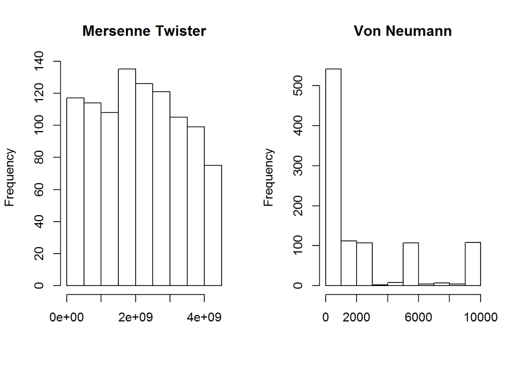

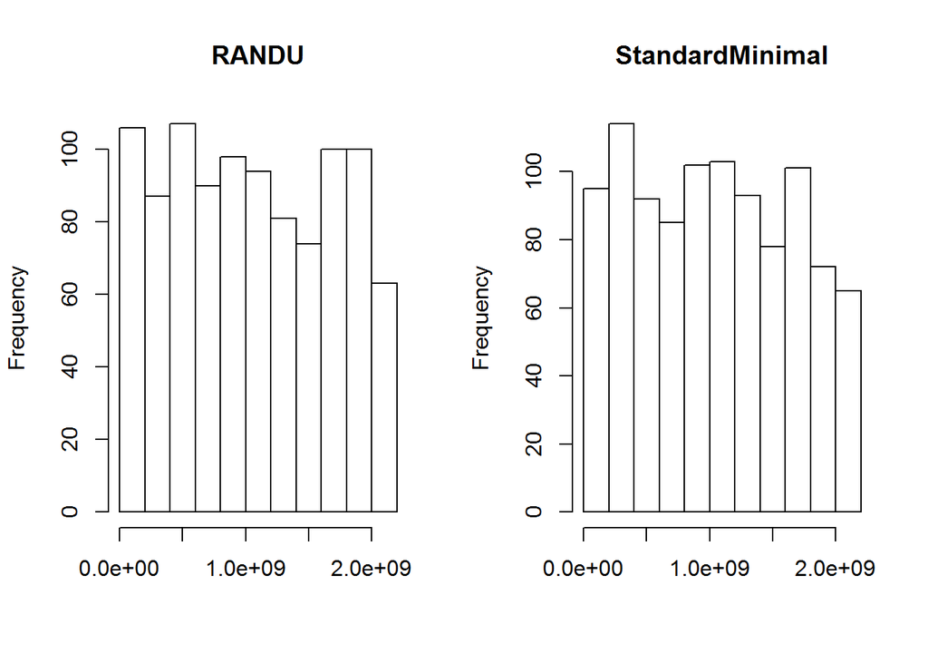

On remarque que le générateur de Von Neumann n’est vraiment pas une distribution uniforme car la majorité des valeurs sont comprises entre 0 et 1000. On peut imaginer que comme les nombres sont obtenus en enlevant les premiers et derniers chiffres de manière symétrique, on se retrouve presque aussi souvent avec 3 chiffres que 4 chiffres mais comme y a 9 fois plus de nombre à 4 chiffres, la répartition est très déséquilibrée. Quant aux autres générateurs, ils sont beaucoup plus uniformes, malgré une tendance à générer moins de chiffres proches de la borne supérieure.

## Question 2.2

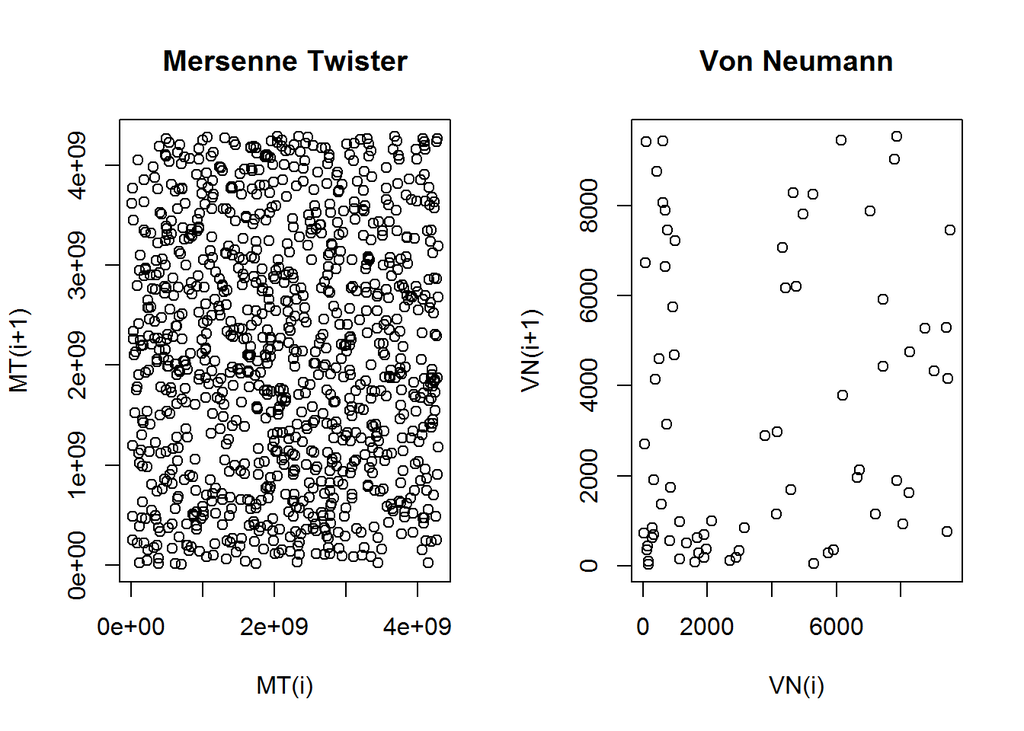

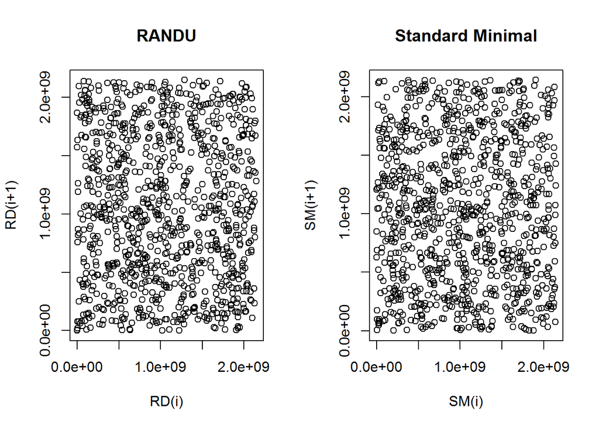

Les générateurs Mersenne Twister, RANDU, Standard Minimal offrent une représentation assez similaire : des valeurs très proches fournissent des valeurs suivantes très différentes (ou éloignées) donc la répartition est assez uniforme. En revanche pour le générateur Von Neumann, on a une concentration des valeurs dans le coin inférieur gauche et les nombres à 4 chiffres sont par exemple inaccessibles depuis l’intervalle [1500; 3500], ce qui explique la répartition non uniforme observée précédement.

## Question 3

Voici le code de la fonction pour le test de fréquence monobit. La fonction prend en entrée un vecteur de nombres obtenus avec une méthode particulière et retourne une valeur qui indique l’acceptabilité d’un générateur (en dessous de 0.01 il n’est pas accepté).

```r
Frequency <- function(x, nb)
{
  somme <- 0
  for (i in (1:length(x)))
  {
    tab <- binary(x[i])
    tabUpdated <- tab
    for(k in length(tab):(length(tab)-nb+1))
    {
      tabUpdated[k] <- 2*tab[k] - 1
      somme <- somme + tabUpdated[k]
    }
  }
  Sobs <- abs(somme) / sqrt(length(x)*nb)
  Pval <- 2*(1-pnorm(Sobs))
  return(Pval)
}
```

Le générateur de MersenneTwister testé sur 32 bits renvoie une valeur de 0.22. Il passe donc le test.  
Les générateurs de RANDU et StandardMinimal passent (avec des valeurs de 0.53 et 0.06). Cependant, il faut les tester sur 31 bits car les valeurs de renvoi sont comprises entre 0 et 2^31 - 1 et 2^31 - 2 respectivement.  
Pour Von Neumann, nous décidons de le tester sur 13 bits. Car sa valeur maximale vaut :

```r
binary(9999)
```

```
##  [1] 0 0 0 0 0 0 0 0 0 0 0 0 0 0 0 0 0 0 1 0 0 1 1 1 0 0 0 0 1 1 1 1
```

On voit que le 14ème bit est a 1, mais malgré le fait que celui ci est visité par l’algorithme, la plupart des valeurs le comprenant ne le sont pas donc il serait inexact de le comptabililser.

Remarque : Pour StandardMinimal, on néglige ce détail au vu du nombre de valeurs.

## Question 4

Voici l’implémentation de la fonction décrite pour le test des runs :

```r
Runs <- function(x,nb)
{
  somme <- 0
  tab <- rep(0,0)
  for (i in (1:length(x)))
  {
    nbBinaire <- binary(x[i])
    tabPartiel <- rep(0,0)
    for(k in (length(nbBinaire)-nb+1) : length(nbBinaire) ){
       tabPartiel[k-length(nbBinaire)+nb] <- nbBinaire[k]
    }
    tab = c(tab,tabPartiel)
  }
    for(k in 1:length(tab))
    {
      if (tab[k] == 1)
      {
        somme <- somme + 1
      }
    }

  n <- (length(x)*nb)
  pi <- somme/n
  if (abs((pi - 0.5)) > 2/sqrt(n))
  {
    return (0)
  }
  else
  {
    r <- 1
    for(k in 1: (length(tab)-1) )
    {
      if (tab[k] != tab[k+1])
      {
        r <- r + 1
      }
    }
  }
  Pval <- 2*(1-pnorm(   abs(r - 2*n*pi*(1-pi))/ (2*sqrt(n)*pi*(1-pi))   ))
  return (Pval)
}
```

Nous appliquons donc cette méthode pour chacun des générateurs sur le même nombre de valeurs que précédemment :

- Von Neumann :

```
## [1] 0
```

- Randu

```
## [1] 0.7521196
```

- Standard Minimal

```
## [1] 0.3591676
```

- Mersenne-Twister

```
## [1] 0.3567837
```

Pour Randu, la valeur est très bonne avec pval = 0.75. Le test des runs passe aussi pour Mersenne-Twister et Standard Minimal avec une valeur de 0.35. Quant au test de Von Neumann, il ne passe encore pas (pval = 0 < 0.01).

## Question 5

Pour le test d’ordre, on utilise la fonction du paquet rantoolbox suivante :

pval <- order.test(u, d=4, echo=FALSE)$p.value

Voici les différents résultats obtenus pour chaque générateur :

- Von Neumann :

```
## [1] 0
```

- Randu

```
## [1] 0.46
```

- Standard Minimal

```
## [1] 0.8
```

- Mersenne-Twister

```
## [1] 0.73
```

Encore une fois, le générateur de Von Neumann ne passe pas le test, avec une pvaleur de 0. Tous les autres le passent , avec une meilleure valeur pour Standard Minimal et Mersenne-Twister que pour Randu.

## Question 6

Voici le code qui retourne en fonction des paramètres des lois d’exponentielles d’arrivées et de départs, et de la durée d’observation les listes comportant les horaires de départ et d’arrivées des personnes

```r
FileMM1 <- function(lambda, mu, D){

  arrivees <- rep(0,0)
  tAct <- rexp(1,rate = lambda)
  tDerniereArrivee <- 0
  i <- 1
  while((tAct + tDerniereArrivee) < D){
    arrivees[i] <- tAct + tDerniereArrivee
    tDerniereArrivee <- arrivees[i]
    tAct <- rexp(1,rate = lambda)
    i<-i+1
  }

  departs <- rep(0,0)
  departs[1]<-arrivees[1] + rexp(1,rate = mu)
  for(k in 2:length(arrivees)){
    tService <- rexp(1,rate = mu)
    if(departs[k-1] < arrivees[k] ){
      if((arrivees[k] + tService )<D){
        departs[k]<-(arrivees[k] + tService)
      } else {
        break
      }
    } else {
      if((departs[k-1] + tService)<D){
        departs[k] <- (departs[k-1] + tService)
      } else {
        break
      }
    }
  }

  ma_liste <- list(arrivees,departs)
  return (ma_liste)
}
```

Voici un exemple pour D = 10, lamba = 1 et mu = 1 :

```
## [[1]]
##  [1] 0.65 1.85 3.86 4.86 5.95 7.44 7.46 8.28 8.61 9.88 9.91
##
## [[2]]
## [1] 1.3 1.9 7.9 8.2
```

## Question 7

Voici le code de la fonction qui prend en paramètre l’instant maximal d’observation D et la liste list composée de la liste des arrivées et de celle des départs et retourne le nombre de personnes présentes dans la file d’attente à chaque minutes jusqu’à D, dans une liste.

```r
NbClientSysteme <- function(list,D){
  tabClasse <- rep(0,D)
  for (i in 1:length(list[[1]])  ) {
   tabClasse[floor(list[[1]][i])+1] <- tabClasse[floor(list[[1]][i])+1] + 1
  }
  for (i in 1:length(list[[2]])  ) {
    tabClasse[floor(list[[2]][i])+1] <- tabClasse[floor(list[[2]][i])+1] - 1
  }

  for(k in 2:length(tabClasse)){
    tabClasse[k]<-tabClasse[k] + tabClasse[k-1]
  }
  return(tabClasse)
}
```

- 8 clients arrivent en moyenne par heure, 15 repartent, observé pendant 12 heures. La file d’attente est maîtrisée, le nombre de personnes qui attendent dépasse rarement 5.

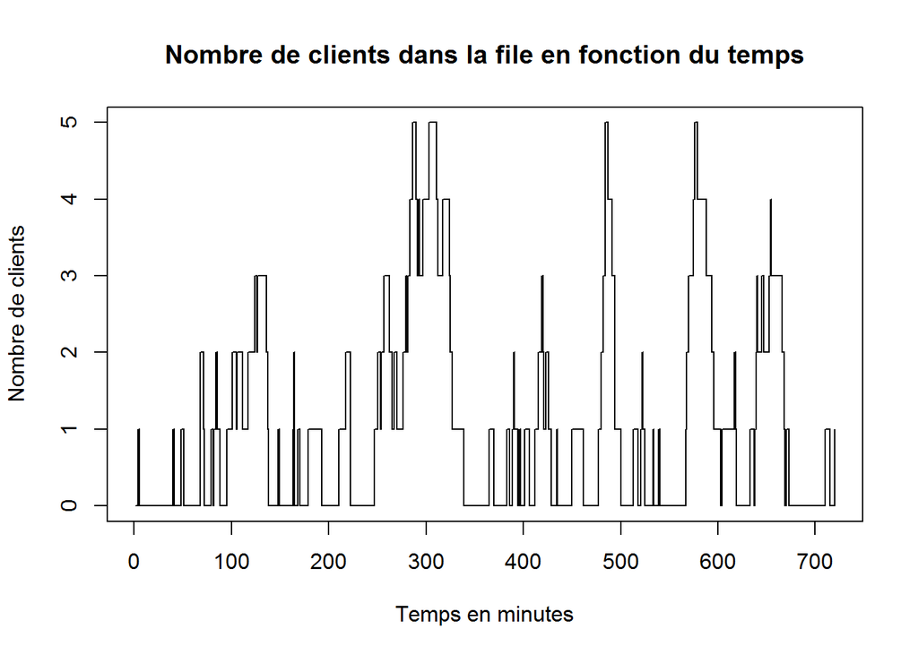

- 14 clients arrivent en moyenne par heure, 15 repartent, observé pendant 12 heures. On est proche de l’équilibre. Le nombre de personnes qui attendent dépasse rarement 15.

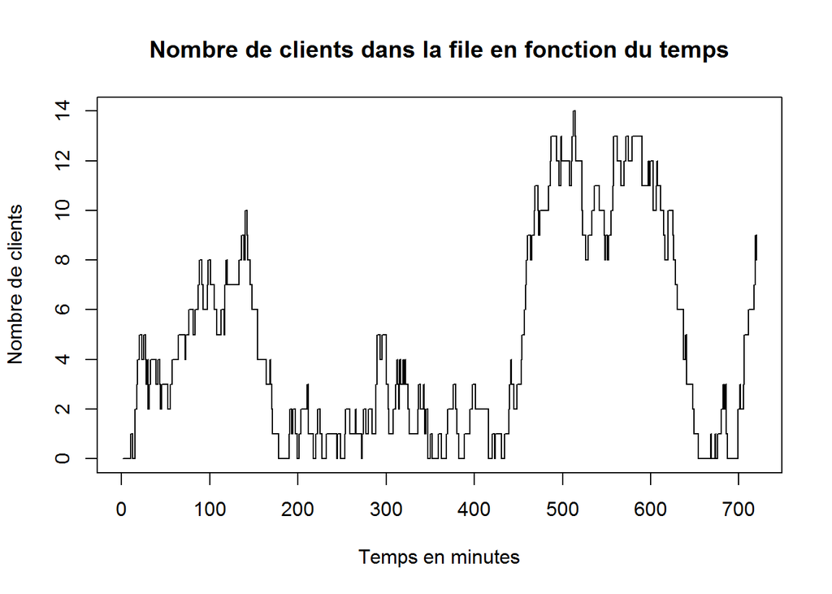

- 15 clients arrivent en moyenne par heure, 15 repartent, observé pendant 12 heures. Le comportement de la file est alors chaotique. Selon les éxécutions, le nombre de personnes peut converger ou diverger.

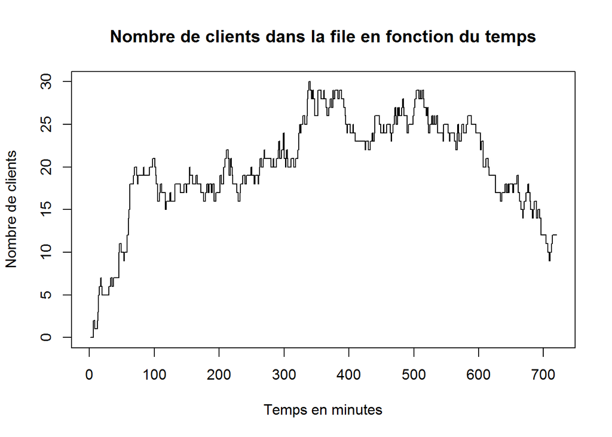

- 20 clients arrivent en moyenne par heure, 15 repartent, observé pendant 12 heures. La file d’attente est maintenant saturée : il y a en moyenne toujours plus de clients qui arrivent que de clients qui partent. L’attente ne fait que croître.

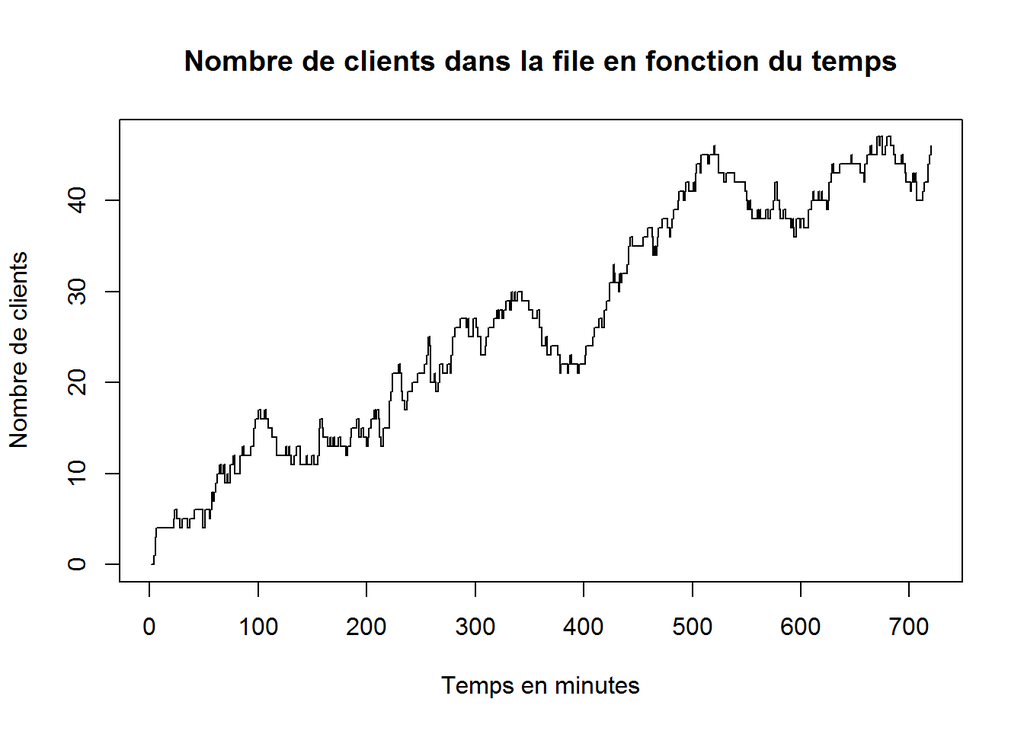

On retrouve par observation l’idée intuitive que l’on a : si le nombre de personne qui arrivent est inférieur au nombre de personne qui partent, l’attente est maîtrisée, elle est saturée dans le cas contraire.

## Question 8

Voici le code permettant de calculer E(W) et E(N) pour vérifier la formule de Little :

```r
Little <- function(list,D,nbClient){
  EN <- 0
  for (i in (1:length(nbClient))) {
    EN <- EN + nbClient[i]
  }
  EN <- EN / length(nbClient)
  EW <- 0
  for (i in (1:min(   length(list[[1]])   ,   length(list[[2]])   ))) {
    EW <- EW + list[[2]][i] - list[[1]][i]
  }
  EW <- EW / min(   length(list[[1]])   ,   length(list[[2]])   )
  return(list(EN,EW))
}
```

Nous avons ensuite testé la validité de la formule de little pour les 4 cas différents.

- 8 arrivent clients par heure et 15 repartent

```
## E(N)=  1.8
```

```
## lambda * E(w) =  1.7
```

- 14 arrivent clients par heure et 15 repartent

```
## E(N)=  3.5
```

```
## lambda * E(w) =  3.6
```

- 15 arrivent clients par heure et 15 repartent

```
## E(N)=  5
```

```
## lambda * E(w) =  5.1
```

- 20 arrivent clients par heure et 15 repartent

```
## E(N)=  32
```

```
## lambda * E(w) =  30
```

# Question Bonus

Pour cette question, la forme de l’algorithme général est la même à savoir :

Arrivée 1ere personne = temps attente  
Arrivée n+1ième personne = arrivée n-ième personne + temps attente

Depart 1ere personne = arrivée 1ere personne + temps passé  
Depart n+1ième personne = Depart n+1ième personne + temps passé SI une des deux caisses est libre  
OU Depart de la n-ième personne + temps passé SI aucune caisse de libre.

La différence et la difficulté, c’est que la derniere personne partie avant le client en question, n’est pas forcément arrivée juste avant ce client la. Il se peut qu’entre temps, plusieurs clients soit passés sur l’autre caisse ou le temps d’attente aurait été plus court pendant quelques passages.  
Il est donc nécessaire de stocker en mémoire à la fois la disponibilité des deux caisses, ainsi que le temps de départ du dernier client parti.